# Dengue Virus Nonstructural Protein 1 Binding to Thrombin as a Dengue Severity Marker: Comprehensive Patient Analysis in South Taiwan

Josephine Diony Nanda, Trai-Ming Yeh, Rahmat Dani Satria, Ming-Kai Jhan, Yung-Ting Wang, Ya-Lan Lin, Chiou-Feng Lin, Herdiantri Sufriyana, Emily Chia-Yu Su, Tzong-Shiann Ho

2024-05-13

This analysis used the second assumption. [**Click here**](https://herdiantrisufriyana.github.io/colab_ns1nst/index.html) for the first assumption.

# Programming environment

We used R 4.4.0. All the analytical codes are publicly shared. However, data access should be requested to the corresponding author.

# Data preprocessing

Briefly, we conducted data cleaning, data tranformation, outlier analysis, removal of categorical variables with perfect separation, and missing data handling before regression analyses.

## Data cleaning

There are 92 rows and 47 columns in raw data.

Variable description.

| no | variable | description |
| --- | --- | --- |
| 1 | batch | SAMPLE ORDER STATUS |
| 2 | id_sample | sample number |
| 3 | id_specimen | 檢體編號 (Specimen number) |
| 4 | physician_group | 何醫師分組 (Physician Ho group) |
| 5 | sex | 性別 (gender) |
| 6 | age | 年齡 (age) |
| 7 | fever_d | Day0 (-發燒日/fever day) |
| 8 | hospital_d | 住院天數 (The number of days in hospital) |
| 9 | icu_d | ICU |
| 10 | severe | 重症 (serious) |
| 11 | wbc | WBC |
| 12 | hb | Hb |
| 13 | hct | Hct |
| 14 | plt | Platelet |
| 15 | got | GOT |
| 16 | gpt | GPT |
| 17 | bil_t | Bil-T |
| 18 | bil_d | Bil-D |
| 19 | ammonia | Ammonia |
| 20 | bun | BUN |
| 21 | cr | Cr |
| 22 | aptt | APTT |
| 23 | pt | PT |
| 24 | alb | Albumin |
| 25 | cm_dm | 1.DM |
| 26 | cm_crf | 2.CRF |
| 27 | cm_hyp | 3.Hypertension |
| 28 | cm_hbv | 4.HBV |
| 29 | cm_hcv | HCV |
| 30 | cm_malignancy | 5.Malignancy |
| 31 | cm_cva | 6.CVA |
| 32 | cm_copd | 7.COPD |
| 33 | cm_asthma | Asthma |
| 34 | cm_gout | 8.Gout |
| 35 | cm_duodenal_ulcer | 9.Duodenal ulcer |
| 36 | cm_other_status | 10.Other…36 |
| 37 | cm_other_condition | 10.Other…37 |
| 38 | ascitis | Ascitis |
| 39 | pi_effusion | PI effusion |
| 40 | ns1_od | NS1 _OD |
| 41 | nst_od | NST_OD |
| 42 | ns1 | NS1 |
| 43 | igg | IgG |
| 44 | igm | IgM |
| 45 | diag_test | 法傳 (Diagnostic Test) |
| 46 | viral_load | 病毒荷量 (Viral Load) |
| 47 | infection | Infection Status |

We removed variables with only 1 category.

```
## cm_malignancy, cm_asthma, cm_gout, cm_duodenal_ulcer
```

Metadata and redundant variables were also removed.

```
## ns1, cm_other_status, diag_test
```

We ensured `physician_group` consistent to the diagnostic rules, i.e.:

Variable `physician_group` was renamed to `outcome`.

Initial variables after data cleaning were categorized into identifier variables, strata variables, dependent variable, independent variables, and covariates.

```
## id: id_sample, id_specimen
##
## strata: batch
##
## dependent: outcome
##
## independent: ns1_od, nst_od
##
## covariates: sex, age, fever_d, wbc, hb, hct, plt, got, gpt, bil_t, bil_d, ammonia, bun, cr, aptt, pt, alb, cm_dm, cm_crf, cm_hyp, cm_hbv, cm_hcv, cm_cva, cm_copd, cm_other_condition, ascitis, pi_effusion, igg, igm, viral_load, infection
```

# Data transformation

We assessed the normality of numerical variables using normal quantile-to-quantile (QQ) plots.

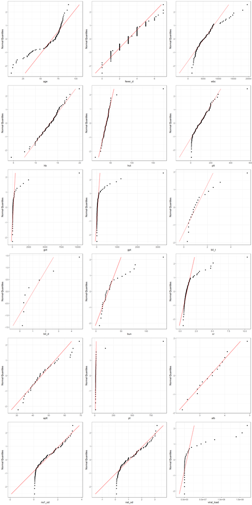

Figure S1. Normal QQ plots of numeric variables. QQ, quantile to quantile.

We determined some variables were normally distributed.

```
## wbc, hct, plt, got, gpt, cr, pt, ns1_od, nst_od
```

Shapiro-Wilk normality tests were also conducted.

Table S2. Normality test.

| variable | statistic | p.value |
| --- | --- | --- |
| gpt* | 0.308 | <0.001 |
| hct* | 0.453 | <0.001 |
| pt* | 0.185 | <0.001 |
| cr* | 0.548 | <0.001 |
| got* | 0.285 | <0.001 |
| viral_load* | 0.548 | <0.001 |
| plt* | 0.852 | <0.001 |
| age* | 0.855 | <0.001 |
| wbc* | 0.876 | <0.001 |
| ns1_od* | 0.889 | <0.001 |
| bun* | 0.742 | <0.001 |
| nst_od* | 0.909 | <0.001 |
| bil_t* | 0.749 | <0.001 |
| fever_d* | 0.958 | 0.005 |
| bil_d* | 0.770 | 0.013 |
| aptt* | 0.941 | 0.042 |
| hb | 0.977 | 0.12 |
| alb | 0.978 | 0.956 |

Note:  
*, p-value <=0.05, Shapiro-Wilk normality test

Some variables were not normally distributed by normality test. Nevertheless, we only applied data transformation to the variables that were neither normally distributed by QQ plots.

```
## age, fever_d, bil_t, bil_d, bun, aptt, viral_load
```

```
## log, sqrt, inv, log2, exp, asinh, bct
```

Yet, if a variable could be transformed such that it was normally distributed, we chose a transformation technique that was easily interpreted beyond Box-Cox transformation if any.

Table S1. Normality test after transformation.

| variable | best_trans | p.value | log | sqrt | inv | log2 | exp | asinh | bct |
| --- | --- | --- | --- | --- | --- | --- | --- | --- | --- |
| age* | bct | <0.001 | <0.001 | <0.001 | <0.001 | <0.001 | <0.001 | <0.001 | <0.001 |
| fever_d* | sqrt | <0.001 | NA | <0.001 | NA | NA | <0.001 | <0.001 | NA |
| viral_load* | asinh | <0.001 | NA | <0.001 | NA | NA | NA | <0.001 | NA |
| bil_d | bct/inv† | 0.553 | 0.399 | 0.105 | 0.43 | 0.399 | <0.001 | 0.086 | 0.553 |
| aptt | inv | 0.818 | 0.498 | 0.184 | 0.818 | 0.498 | <0.001 | 0.498 | 0.817 |
| bun | bct/log† | 0.902 | 0.367 | 0.002 | 0.025 | 0.367 | <0.001 | 0.362 | 0.902 |
| bil_t | bct/log† | 0.925 | 0.706 | 0.025 | 0.12 | 0.706 | <0.001 | 0.057 | 0.925 |

Note:  
*, p-value <=0.05, Shapiro-Wilk normality test; †, normal without BCT

Some numerical variables were not normal after transformation.

```
## age, fever_d, viral_load
```

We applied categorization based on common or domain-specific knowledge, avoiding data-driven bias.

Categorization for variables that are not normal after transformation.

| variable | category | cutoff |
| --- | --- | --- |
| age | <=65 | 65 |
| age | >65 | Inf |
| fever_d | 1 | 1 |
| fever_d | 2 | 2 |
| fever_d | 3 | 3 |
| fever_d | 4 | 4 |
| fever_d | 5+ | Inf |
| viral_load | negative | 0 |
| viral_load | positive | Inf |

Note:  
A category was defined if a value was less or equal to cutoff.

Another categorical variable was also recategorized into several variables.

```
## cm_other_condition_af, cm_other_condition_arf, cm_other_condition_bph, cm_other_condition_cad, cm_other_condition_chf, cm_other_condition_ckd, cm_other_condition_colon_cancer, cm_other_condition_dementia, cm_other_condition_djd_bil_knee, cm_other_condition_epilepsy, cm_other_condition_esrd, cm_ot…
```

# Outlier analysis

After transformation into normal distribution, numerical variables were identified for outliers. A value was an outlier if it was either less than Q1 or greater than Q3 by 1.5 IQR (i.e., Q3-Q1).

Outlier proportions of numerical variables.

| variable | p_outliers |
| --- | --- |
| gpt | 14.10 |
| got | 13.95 |
| cr | 12.16 |
| wbc | 5.43 |
| pt | 4.88 |
| hct | 4.62 |
| bun | 3.12 |
| hb | 2.30 |
| plt | 1.09 |
| alb | 0.00 |
| aptt | 0.00 |
| bil_d | 0.00 |
| bil_t | 0.00 |
| ns1_od | 0.00 |
| nst_od | 0.00 |

We assigned outliers to missing values which would be imputed later as a technique we chose to deal with outliers.

# Removal of categorical variables with perfect separation

Some categorical variables were removed if they were perfectly separated across groups of the dependent variable. Perfect separation is likely due to sampling error, except there was a clear justification that explains such data generation was possible. In this study, no such justification existed.

There were some categorical variables with perfect separation.

```
## ammonia, ascitis, cm_hbv, cm_hcv, cm_other_condition_af, cm_other_condition_arf, cm_other_condition_bph, cm_other_condition_cad, cm_other_condition_chf, cm_other_condition_colon_cancer, cm_other_condition_dementia, cm_other_condition_djd_bil_knee, cm_other_condition_epilepsy, cm_other_condition_e…
```

We also checked if perfect separation existed for the missingness of the variables. We would assess a missingness later to check if a variable was missing completely at random.

Nevertheless, only 1 missing value for plt, which was considerably negligible. While 15 non-missing values of alb and 7 and 5 missing values of respectively hb and wbc were perfectly separated, we also considered this negligible.

```
## alb, hb, wbc, plt
```

Eventually, we excluded categorical variables with perfect separation.

# Missing data handling

To deal with missing values, we determined if variables were missing completely at random (MCAR). It was identified by identifying if there was an association between its missingness and the values of the dependent and independent variables.

Several variables had no missing values, including strata, dependent, and independent variables.

```
## batch, outcome, ns1_od, nst_od, age, fever_d, sex, cm_dm, cm_crf, cm_hyp, cm_cva, cm_copd, infection
```

Some variables had missing values, all of which were the covariates.

```
## wbc, hb, hct, plt, got, gpt, cr, pt, alb, aptt, bil_d, bil_t, bun, viral_load, cm_other_condition_ckd, igg, igm
```

Table S3. Association between covariate missingness and independent/dependent variable values.

| dep_var | indep_var | p.value |
| --- | --- | --- |
| ns1_od | igg* | 0.009 |
| ns1_od | igm* | 0.009 |
| ns1_od | bil_d* | 0.011 |
| ns1_od | cm_other_condition_ckd* | 0.034 |
| ns1_od | bun | 0.105 |
| ns1_od | aptt | 0.126 |
| ns1_od | viral_load | 0.239 |
| ns1_od | pt | 0.315 |
| ns1_od | gpt | 0.337 |
| ns1_od | hct | 0.398 |
| ns1_od | bil_t | 0.401 |
| ns1_od | got | 0.763 |
| ns1_od | cr | 0.944 |
| nst_od | igg* | 0.007 |
| nst_od | igm* | 0.007 |
| nst_od | bil_d* | 0.015 |
| nst_od | cm_other_condition_ckd* | 0.044 |
| nst_od | bun | 0.135 |
| nst_od | aptt | 0.205 |
| nst_od | hct | 0.218 |
| nst_od | gpt | 0.232 |
| nst_od | viral_load | 0.328 |
| nst_od | pt | 0.514 |
| nst_od | got | 0.788 |
| nst_od | bil_t | 0.901 |
| nst_od | cr | 0.998 |
| outcome | igg† | 0.019 |
| outcome | igm† | 0.019 |
| outcome | aptt | 0.053 |
| outcome | bil_t | 0.058 |
| outcome | bun | 0.064 |
| outcome | viral_load | 0.09 |
| outcome | pt | 0.125 |
| outcome | hct | 0.466 |
| outcome | gpt | 0.512 |
| outcome | bil_d | 0.585 |
| outcome | got | 0.691 |
| outcome | cm_other_condition_ckd | 0.728 |
| outcome | cr | 0.842 |

Note:  
†, p-value <=0.05, two-sided, Fisher’s Exact Test for Count; *, p-value <=0.05, two-sided, Welch Two Sample t-test; CI, confidence interval

Some variables with missing values were MCAR; hence, we could apply imputation for these variables.

```
## hct, got, gpt, cr, pt, aptt, bil_t, bun, viral_load, alb, hb, wbc, plt
```

We applied multiple imputation by chained equation (MICE). The missing values were imputed for 10 times by predictive mean matching method.

Statistical tests were also conducted to identify if there were differences before and after imputation for each variable.

Table S4. Difference of before and after imputation.

| var | estimate | p.value | conf.low | conf.high |
| --- | --- | --- | --- | --- |
| bun* | 0.315 | 0.016 | 0.061 | 0.569 |
| pt* | -0.913 | 0.043 | -1.797 | -0.028 |
| aptt | -0.001 | 0.121 | -0.003 | 0.000 |
| bil_t | -0.294 | 0.158 | -0.708 | 0.121 |
| alb | -0.211 | 0.278 | -0.607 | 0.185 |
| cr | -0.053 | 0.402 | -0.179 | 0.072 |
| got | -9.087 | 0.6 | -43.531 | 25.357 |
| gpt | -1.959 | 0.669 | -10.985 | 7.067 |
| hct | -0.396 | 0.694 | -2.381 | 1.589 |
| wbc | -145.415 | 0.732 | -982.886 | 692.056 |
| hb | -0.065 | 0.838 | -0.693 | 0.563 |
| plt | 0.929 | 0.928 | -19.405 | 21.263 |
| viral_load | Inf | 1 | 0.000 | Inf |

Note:  
†, p-value <=0.05, one-sided (less), Fisher’s Exact Test for Count; *, p-value <=0.05, two-sided, Welch Two Sample t-test; CI, confidence interval

Data distribution of the imputed variables were mostly similar before and after imputation.

```
## hct, got, gpt, cr, aptt, bil_t, viral_load, alb, hb, wbc, plt
```

# Descriptive statistics

We included 24 variables for the downstream analyses, including strata, dependent, and independent variables.

Number of covariates every time a step removing some.

[output not shown]

Table 1. Sample characteristics

| variable | value | A (n=26) | B (n=32) | C (n=34) |
| --- | --- | --- | --- | --- |
| batch | first % (n) | 38 (10) | 25 (8) | 35 (12) |
| batch | second % (n) | 62 (16) | 75 (24) | 65 (22) |
| ns1_od | average (SD) | 0.57 (0.57) | 1.47 (0.91) | 1.07 (1.01) |
| nst_od | average (SD) | 0.61 (0.61) | 1.51 (0.83) | 1.24 (0.98) |
| age | <=65 % (n) | 73 (19) | 31 (10) | 29 (10) |
| age | >65 % (n) | 27 (7) | 69 (22) | 71 (24) |
| fever_d | 1 % (n) | 31 (8) | 19 (6) | 9 (3) |
| fever_d | 2 % (n) | 15 (4) | 16 (5) | 21 (7) |
| fever_d | 3 % (n) | 23 (6) | 19 (6) | 24 (8) |
| fever_d | 4 % (n) | 19 (5) | 28 (9) | 21 (7) |
| fever_d | 5+ % (n) | 12 (3) | 19 (6) | 26 (9) |
| sex | F % (n) | 35 (9) | 69 (22) | 32 (11) |
| sex | M % (n) | 65 (17) | 31 (10) | 68 (23) |
| cm_dm | no % (n) | 92 (24) | 62 (20) | 59 (20) |
| cm_dm | yes % (n) | 8 (2) | 38 (12) | 41 (14) |
| cm_crf | no % (n) | 96 (25) | 91 (29) | 91 (31) |
| cm_crf | yes % (n) | 4 (1) | 9 (3) | 9 (3) |
| cm_hyp | no % (n) | 81 (21) | 66 (21) | 29 (10) |
| cm_hyp | yes % (n) | 19 (5) | 34 (11) | 71 (24) |
| cm_cva | no % (n) | 96 (25) | 97 (31) | 91 (31) |
| cm_cva | yes % (n) | 4 (1) | 3 (1) | 9 (3) |
| cm_copd | no % (n) | 96 (25) | 91 (29) | 97 (33) |
| cm_copd | yes % (n) | 4 (1) | 9 (3) | 3 (1) |
| infection | primary % (n) | 81 (21) | 81 (26) | 62 (21) |
| infection | secondary % (n) | 19 (5) | 19 (6) | 38 (13) |
| hct | average (SD) | 41.25 (4.99) | 40.35 (6.02) | 39.18 (6.66) |
| got | average (SD) | 71.88 (62.6) | 89.94 (83.87) | 150.15 (101.09) |
| gpt | average (SD) | 28.54 (24.87) | 35.22 (27.77) | 47.18 (30.03) |
| cr | average (SD) | 1.06 (0.4) | 0.94 (0.35) | 1.15 (0.45) |
| aptt | average (SD) | 43.18 (6.32) | 42.58 (8.58) | 45.61 (10.72) |
| bil_t | average (SD) | 2.37 (1.56) | 1.55 (1.43) | 1.83 (1.43) |
| viral_load | negative % (n) | 46 (12) | 12 (4) | 15 (5) |
| viral_load | positive % (n) | 54 (14) | 88 (28) | 85 (29) |
| alb | average (SD) | 4.03 (0.52) | 3.56 (0.61) | 3.41 (0.81) |
| hb | average (SD) | 13.72 (1.65) | 13.31 (2.16) | 12.96 (2.43) |
| wbc | average (SD) | 4700 (1818.35) | 5325 (3147.86) | 6302.94 (3103.32) |
| plt | average (SD) | 139.08 (49.44) | 100.69 (81.73) | 62.76 (51.89) |

# Univariate regression analysis

We conducted univariate regression analysis for the independent variables and their covariates. Batch effect might result in unwanted bias and should be adjusted if any.

Table S6. Univariate regression analysis.

| y.level | variable | term | estimate | std.error | statistic | p.value | OR | LB | UB |
| --- | --- | --- | --- | --- | --- | --- | --- | --- | --- |
| BC vs. A | age* | >65 | 1.831 | 0.517 | 3.543 | <0.001 | 6.243 | 2.267 | 1.719500e+01 |
| BC vs. A | nst_od* | value | 1.296 | 0.392 | 3.303 | 0.001 | 3.656 | 1.694 | 7.888000e+00 |
| BC vs. A | viral_load* | positive | 1.692 | 0.532 | 3.178 | 0.001 | 5.429 | 1.912 | 1.541100e+01 |
| BC vs. A | plt* | value | -0.013 | 0.004 | -3.354 | 0.001 | 0.987 | 0.980 | 9.950000e-01 |
| BC vs. A | alb* | value | -1.322 | 0.431 | -3.071 | 0.002 | 0.266 | 0.115 | 6.200000e-01 |
| BC vs. A | ns1_od* | value | 1.068 | 0.361 | 2.959 | 0.003 | 2.910 | 1.434 | 5.905000e+00 |
| BC vs. A | cm_hyp* | yes | 1.556 | 0.555 | 2.802 | 0.005 | 4.742 | 1.597 | 1.408300e+01 |
| BC vs. A | cm_dm* | yes | 2.054 | 0.778 | 2.641 | 0.008 | 7.800 | 1.698 | 3.583000e+01 |
| BC vs. A | got* | value | 0.008 | 0.003 | 2.215 | 0.027 | 1.008 | 1.001 | 1.014000e+00 |
| BC vs. A | bil_t* | value | -0.574 | 0.278 | -2.066 | 0.039 | 0.563 | 0.327 | 9.710000e-01 |
| BC vs. A | gpt | value | 0.019 | 0.010 | 1.884 | 0.06 | 1.019 | 0.999 | 1.040000e+00 |
| BC vs. A | fever_d | 5+ | 1.492 | 0.798 | 1.870 | 0.061 | 4.444 | 0.931 | 2.121800e+01 |
| BC vs. A | wbc | value | 0.000 | 0.000 | 1.681 | 0.093 | 1.000 | 1.000 | 1.000000e+00 |
| BC vs. A | fever_d | 4 | 1.045 | 0.706 | 1.480 | 0.139 | 2.844 | 0.713 | 1.135100e+01 |
| BC vs. A | sex | M | -0.636 | 0.480 | -1.325 | 0.185 | 0.529 | 0.207 | 1.357000e+00 |
| BC vs. A | fever_d | 2 | 0.981 | 0.755 | 1.300 | 0.194 | 2.667 | 0.608 | 1.170300e+01 |
| BC vs. A | hb | value | -0.135 | 0.114 | -1.188 | 0.235 | 0.874 | 0.699 | 1.092000e+00 |
| BC vs. A | hct | value | -0.044 | 0.040 | -1.086 | 0.278 | 0.957 | 0.885 | 1.036000e+00 |
| BC vs. A | fever_d | 3 | 0.730 | 0.689 | 1.059 | 0.289 | 2.074 | 0.538 | 7.998000e+00 |
| BC vs. A | infection | secondary | 0.529 | 0.567 | 0.934 | 0.351 | 1.698 | 0.559 | 5.159000e+00 |
| BC vs. A | cm_crf | yes | 0.916 | 1.106 | 0.828 | 0.407 | 2.500 | 0.286 | 2.184800e+01 |
| BC vs. A | batch | second | 0.363 | 0.484 | 0.750 | 0.453 | 1.437 | 0.557 | 3.712000e+00 |
| BC vs. A | cm_cva | yes | 0.478 | 1.143 | 0.418 | 0.676 | 1.613 | 0.172 | 1.515000e+01 |
| BC vs. A | cm_copd | yes | 0.478 | 1.143 | 0.418 | 0.676 | 1.613 | 0.172 | 1.515000e+01 |
| BC vs. A | cr | value | -0.067 | 0.562 | -0.119 | 0.905 | 0.935 | 0.311 | 2.815000e+00 |
| BC vs. A | aptt | value | 4.425 | 49.233 | 0.090 | 0.928 | 83.494 | 0.000 | 6.740505e+43 |
| C vs. B | sex* | M | 1.526 | 0.529 | 2.885 | 0.004 | 4.600 | 1.631 | 1.297300e+01 |
| C vs. B | cm_hyp* | yes | 1.522 | 0.529 | 2.875 | 0.004 | 4.582 | 1.624 | 1.293000e+01 |
| C vs. B | got* | value | 0.007 | 0.003 | 2.435 | 0.015 | 1.007 | 1.001 | 1.013000e+00 |
| C vs. B | plt* | value | -0.008 | 0.004 | -2.131 | 0.033 | 0.992 | 0.984 | 9.990000e-01 |
| C vs. B | cr* | value | 1.342 | 0.682 | 1.966 | 0.049 | 3.826 | 1.004 | 1.457400e+01 |
| C vs. B | infection | secondary | 0.987 | 0.574 | 1.719 | 0.086 | 2.683 | 0.871 | 8.266000e+00 |
| C vs. B | ns1_od | value | -0.441 | 0.264 | -1.667 | 0.096 | 0.644 | 0.383 | 1.081000e+00 |
| C vs. B | gpt | value | 0.015 | 0.009 | 1.631 | 0.103 | 1.015 | 0.997 | 1.033000e+00 |
| C vs. B | wbc | value | 0.000 | 0.000 | 1.260 | 0.208 | 1.000 | 1.000 | 1.000000e+00 |
| C vs. B | fever_d | 5+ | 1.099 | 0.882 | 1.246 | 0.213 | 3.000 | 0.533 | 1.689700e+01 |
| C vs. B | nst_od | value | -0.330 | 0.277 | -1.190 | 0.234 | 0.719 | 0.417 | 1.238000e+00 |
| C vs. B | bil_t | value | 0.312 | 0.273 | 1.142 | 0.253 | 1.366 | 0.800 | 2.332000e+00 |
| C vs. B | fever_d | 2 | 1.030 | 0.918 | 1.122 | 0.262 | 2.800 | 0.463 | 1.692900e+01 |
| C vs. B | fever_d | 3 | 0.981 | 0.890 | 1.102 | 0.27 | 2.667 | 0.466 | 1.525200e+01 |
| C vs. B | aptt | value | -53.201 | 49.116 | -1.083 | 0.279 | 0.000 | 0.000 | 5.043922e+18 |
| C vs. B | cm_copd | yes | -1.228 | 1.182 | -1.038 | 0.299 | 0.293 | 0.029 | 2.973000e+00 |
| C vs. B | cm_cva | yes | 1.099 | 1.182 | 0.929 | 0.353 | 3.000 | 0.296 | 3.044400e+01 |
| C vs. B | batch | second | -0.492 | 0.544 | -0.906 | 0.365 | 0.611 | 0.211 | 1.773000e+00 |
| C vs. B | alb | value | -0.286 | 0.349 | -0.820 | 0.412 | 0.751 | 0.379 | 1.489000e+00 |
| C vs. B | hct | value | -0.030 | 0.040 | -0.752 | 0.452 | 0.971 | 0.898 | 1.049000e+00 |
| C vs. B | hb | value | -0.069 | 0.109 | -0.630 | 0.529 | 0.933 | 0.754 | 1.156000e+00 |
| C vs. B | fever_d | 4 | 0.442 | 0.868 | 0.509 | 0.611 | 1.556 | 0.284 | 8.531000e+00 |
| C vs. B | cm_dm | yes | 0.154 | 0.505 | 0.305 | 0.76 | 1.167 | 0.434 | 3.137000e+00 |
| C vs. B | viral_load | positive | -0.188 | 0.721 | -0.261 | 0.794 | 0.829 | 0.202 | 3.406000e+00 |
| C vs. B | age | >65 | 0.087 | 0.536 | 0.162 | 0.871 | 1.091 | 0.382 | 3.118000e+00 |
| C vs. B | cm_crf | yes | -0.067 | 0.856 | -0.078 | 0.938 | 0.935 | 0.175 | 5.012000e+00 |

Note:  
*, p-value <=0.05.

# Multivariate regression analysis

A multivariate regression analysis for a variable if it was significantly correlated with the dependent variable by univariate regression analysis. Using correlation tests and its hypothetical direction, we determined covariates for a variable in its multivariate regression analysis.

## Correlation tests

We conducted correlation tests exhaustively for each pair of variables that are significantly associated with the outcome. The multiple-testing effect is corrected by the Benjamini-Hochberg method.

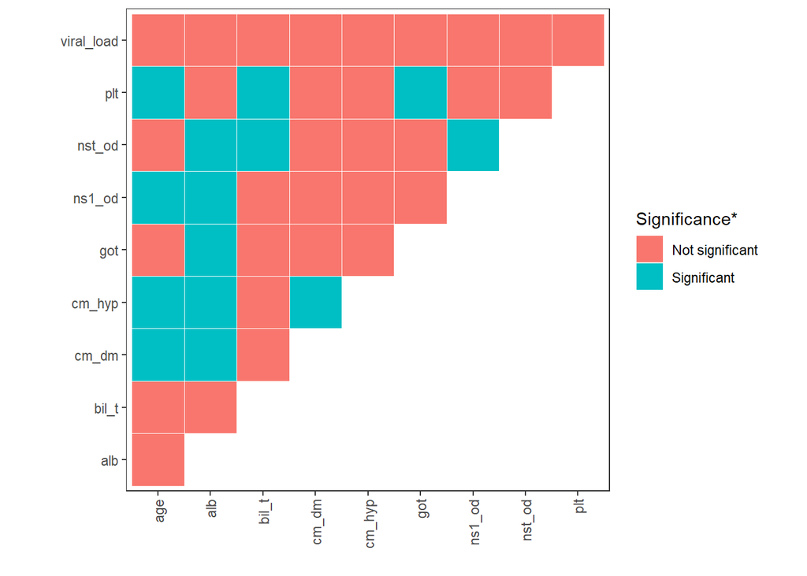

Figure S2. Correlation tests. *, corrected for the multiple-testing effect by the Benjamini-Hochberg method.

Among variable pairs with significant correlation, we determined hypothetical directions of the correlations based on common and domain-specific knowledge.

Table S5. Hypothetical directions of the correlations.

[output not shown]

The hypothetical directions were used to determine covariates for adjusting the effects of the independent variables. We only included the confounders as the covariates, i.e., common variables that affect both the independent and dependent variables.

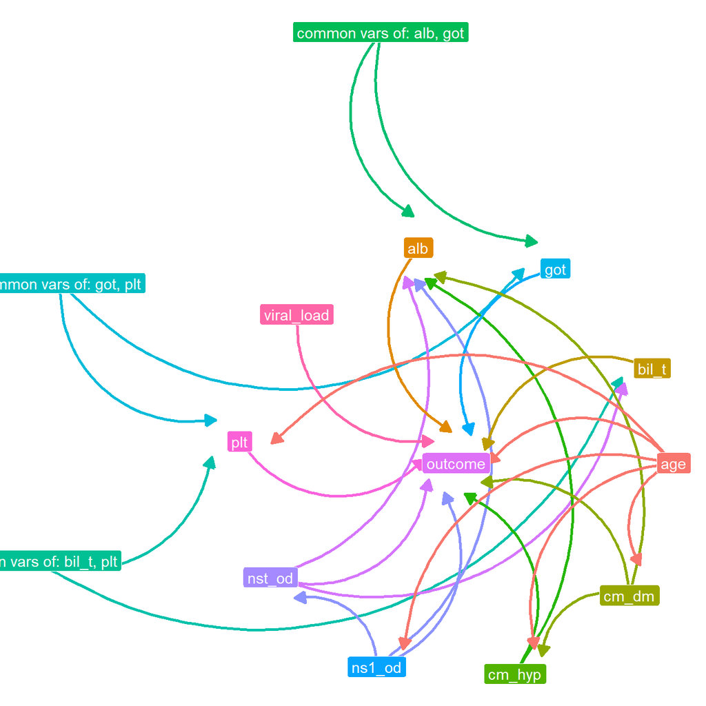

Figure S3. Hypothetical directions of the correlations.

Table S7. Significant correlation to NS1.

| from | to | p.value | hypothesis |
| --- | --- | --- | --- |
| age | ns1_od | 0.007 | age affects NS1 |

Note:  
p-value was corrected for the multiple testing effect by the Benjamini-Hochberg method.

## Confounding adjustment

We adjust the effects of `ns1_od` using its confounders.

Table 2. Multivariate regression analysis.

| variable | covariates | term | estimate | std.error | statistic | p.value | OR | LB | UB |
| --- | --- | --- | --- | --- | --- | --- | --- | --- | --- |
| ns1_od* | age | value | 0.903 | 0.38 | 2.375 | 0.018 | 2.467 | 1.171 | 5.197 |

Note:  
*, p-value <=0.05.

## Mediation analysis

We adjust the effects of `ns1_od` using its confounders and mediators, including `nst_od`.

Table S8. Significant correlation from NS1.

| from | to | p.value | hypothesis |
| --- | --- | --- | --- |
| ns1_od | nst_od | <0.001 | NS1 effect is mediated by NST |
| ns1_od | alb | 0.001 | NS1 affects albumin |

Note:  
*, p-value <=0.05.

Since the sample size only allowed for 1 covariate in addition to `ns1_od`, we reduced the number of covariates without leaking information of the dependent variable as the outcome. Principal component analysis was conducted for this purpose.

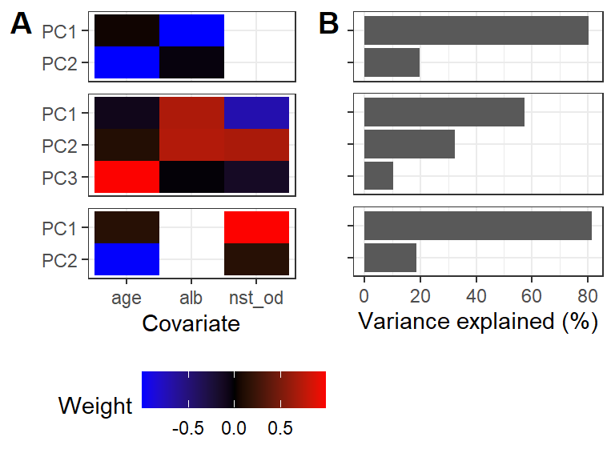

All the covariates of `ns1_od` could be reduced into 1 covariate using PC1.

Now, we conducted mediation analysis whether `ns1_od` effect on the dependent variable persisted without the mediators’ effect, including `nst_od`.

Table 3. Mediation analysis.

| variable | covariates | mediators | term | estimate | std.error | statistic | p.value | OR | LB | UB |
| --- | --- | --- | --- | --- | --- | --- | --- | --- | --- | --- |
| ns1_od* | age | alb | value | 0.919 | 0.376 | 2.442 | 0.015 | 2.508 | 1.199 | 5.245 |
| ns1_od | age | nst_od | value | -2.461 | 1.532 | -1.606 | 0.108 | 0.085 | 0.004 | 1.719 |
| ns1_od | age | alb+nst_od | value | -0.249 | 0.537 | -0.463 | 0.643 | 0.780 | 0.272 | 2.236 |

Note:  
*, p-value <=0.05.

There was no significant effect of `ns1_od` on the dependent variable beyond the `nst_od` effect. In contrast, the effect of `ns1_od` on the dependent variable persisted without another mediator.

# Conclusion

The effect of `ns1_od` on the dependent variable was mediated by `nst_od`.